# Predicting Wine Taste Preferences

This workspace is used to critically analyse the wine data in order to determine if the wine tastes 'good' or 'bad'. Minor EDA was conducted to determine some relationships between variables and possible extreme values. The model to predict the wine quality was built using three different approaches, forward stepwise, ridge and lasso.

The format of the data is a csv, where the Wine_training.csv was used as the training set and Wine_testing.csv was used as the test set. Cross validation was performed and using both predictive accuracy and area under curve as a measurement of predictive performance.

The best model was compared by testing it on the training set to get the predictive performance.

> ggplot2, reshape2, e1071 and gridextra - used to plot graphs and arrange it

> ROCR - calculate the AUC for prediction performance

> glmnet and boot - perform lasso and ridge regression

# Library

```r
library(ggplot2) #visualisation of the data
library(reshape2) #reshaping the data into row format
library(e1071) #needed for analysis
library(gridExtra) #arrangment of plots
#library(lattice)
library(ROCR) #producing AUC for glm
library(glmnet) #lasso and ridge
library(boot) #cross validation lasso and ridge
```

# Reading in the file

```r
wine <- read.csv('Wine_training.csv') #reads in the csv as wine - training
test_wine <- read.csv('Wine_testing.csv') #reads in the csv as wine - testing
```

# Structure of the data

```r
cat('Dimension of the data')
c('dimensions: ', + dim(wine)) # concatenating string to dimension
cat('\nColumn names')
data.frame(names(wine)) # list all column names
cat('\nData type of each columns\n')
str(wine) #structure of the data and data format
cat('\nResponse variable representation')
contrasts(wine$quality)
cat('\nOverview of the first 5 rows of the wine data')
head(wine, 5) #checks the first 5 rows
```

```
Dimension of the data
```

1. 'dimensions: '

2. '3283'

3. '12'

```
Column names
```

|  | names.wine. |
| --- | --- |
| 1 | fixed.acidity |
| 2 | volatile.acidity |
| 3 | citric.acid |
| 4 | residual.sugar |
| 5 | chlorides |
| 6 | free.sulfur.dioxide |
| 7 | total.sulfur.dioxide |
| 8 | density |
| 9 | pH |
| 10 | sulphates |
| 11 | alcohol |
| 12 | quality |

```
Data type of each columns
'data.frame':	3283 obs. of  12 variables:
 $ fixed.acidity       : num  7 6.3 7.2 8.1 6.2 8.1 7.9 6.6 8.3 6.6 ...
 $ volatile.acidity    : num  0.27 0.3 0.23 0.28 0.32 0.27 0.18 0.16 0.42 0.17 ...
 $ citric.acid         : num  0.36 0.34 0.32 0.4 0.16 0.41 0.37 0.4 0.62 0.38 ...
 $ residual.sugar      : num  20.7 1.6 8.5 6.9 7 ...
 $ chlorides           : num  0.045 0.049 0.058 0.05 0.045 0.033 0.04 0.044 0.04 0.032 ...
 $ free.sulfur.dioxide : num  45 14 47 30 30 11 16 48 41 28 ...
 $ total.sulfur.dioxide: num  170 132 186 97 136 63 75 143 172 112 ...
 $ density             : num  1.001 0.994 0.996 0.995 0.995 ...
 $ pH                  : num  3 3.3 3.19 3.26 3.18 2.99 3.18 3.54 2.98 3.25 ...
 $ sulphates           : num  0.45 0.49 0.4 0.44 0.47 0.56 0.63 0.52 0.67 0.55 ...
 $ alcohol             : num  8.8 9.5 9.9 10.1 9.6 12 10.8 12.4 9.7 11.4 ...
 $ quality             : Factor w/ 2 levels "bad","good": 2 2 2 2 2 1 1 2 1 2 ...

Response variable representation
```

|  | good |
| --- | --- |
| bad | 0 |
| good | 1 |

```
Overview of the first 5 rows of the wine data
```

|  | fixed.acidity | volatile.acidity | citric.acid | residual.sugar | chlorides | free.sulfur.dioxide | total.sulfur.dioxide | density | pH | sulphates | alcohol | quality |
| --- | --- | --- | --- | --- | --- | --- | --- | --- | --- | --- | --- | --- |
| 1 | 7 | 0.27 | 0.36 | 20.7 | 0.045 | 45 | 170 | 1.001 | 3 | 0.45 | 8.8 | good |
| 2 | 6.3 | 0.3 | 0.34 | 1.6 | 0.049 | 14 | 132 | 0.994 | 3.3 | 0.49 | 9.5 | good |
| 3 | 7.2 | 0.23 | 0.32 | 8.5 | 0.058 | 47 | 186 | 0.9956 | 3.19 | 0.4 | 9.9 | good |
| 4 | 8.1 | 0.28 | 0.4 | 6.9 | 0.05 | 30 | 97 | 0.9951 | 3.26 | 0.44 | 10.1 | good |
| 5 | 6.2 | 0.32 | 0.16 | 7 | 0.045 | 30 | 136 | 0.9949 | 3.18 | 0.47 | 9.6 | good |

#### Review of the structure of the wine data:

The structure of the data is shown above. As shown there are 3283 rows and 12 attributes in total, with the first 11 being predictors and the last one being the response variable. Within the response variable, 1 refers to good and 0 refers to bad.

**Table of Attributes**

| Attributes | Data Types | Category |
| --- | --- | --- |
| Fixed acidity | Numerical | Continuous |
| Volatile acidity | Numerical | Continuous |
| Citric acid | Numerical | Continuous |
| Residual sugar | Numerical | Continuous |
| Chlorides | Numerical | Continuous |
| Free sulfur dioxide | Numerical | Continuous |
| Total sulfur dioxide | Numerical | Continuous |
| Density | Numerical | Continuous |
| pH | Numerical | Continuous |
| Sulphates | Numerical | Continuous |
| Alcohol | Numerical | Continuous |
| Quality** | Categorical | Nominal |

** response variable

All of the predictors are continous numerical attributes. They are all measurements of the chemical compoud in the wine. UCL site also states that attribute are continous.

https://archive.ics.uci.edu/ml/datasets/Wine

### Statistical summary of each columns of the data

```r
cat('Statistical Summary')
summary(wine) #statistical summary of the data
good <- sum(wine$quality == 'good') / nrow(wine) * 100 #calculating the percentage of occurences
bad <- sum(wine$quality == 'bad') / nrow(wine) * 100
cat('\nPercentage of Good vs Bad\n')
cat('Good: ', round(good, 2), '%    ')
cat('Bad: ', round(bad, 2), '%')
```

```
Statistical Summary
```

```
 fixed.acidity    volatile.acidity  citric.acid     residual.sugar
 Min.   : 3.800   Min.   :0.0800   Min.   :0.0000   Min.   : 0.600
 1st Qu.: 6.300   1st Qu.:0.2100   1st Qu.:0.2700   1st Qu.: 1.700
 Median : 6.800   Median :0.2600   Median :0.3200   Median : 4.800
 Mean   : 6.852   Mean   :0.2803   Mean   :0.3357   Mean   : 6.031
 3rd Qu.: 7.300   3rd Qu.:0.3275   3rd Qu.:0.3900   3rd Qu.: 9.000
 Max.   :14.200   Max.   :1.1000   Max.   :1.6600   Max.   :65.800
   chlorides       free.sulfur.dioxide total.sulfur.dioxide    density
 Min.   :0.00900   Min.   :  2.00      Min.   :  9.0        Min.   :0.9871
 1st Qu.:0.03600   1st Qu.: 23.00      1st Qu.:107.0        1st Qu.:0.9917
 Median :0.04300   Median : 33.00      Median :133.0        Median :0.9936
 Mean   :0.04604   Mean   : 35.05      Mean   :137.7        Mean   :0.9938
 3rd Qu.:0.05000   3rd Qu.: 45.00      3rd Qu.:166.0        3rd Qu.:0.9958
 Max.   :0.34600   Max.   :289.00      Max.   :440.0        Max.   :1.0390
       pH          sulphates         alcohol      quality
 Min.   :2.720   Min.   :0.2200   Min.   : 8.40   bad :1105
 1st Qu.:3.090   1st Qu.:0.4100   1st Qu.: 9.50   good:2178
 Median :3.180   Median :0.4800   Median :10.40
 Mean   :3.195   Mean   :0.4904   Mean   :10.58
 3rd Qu.:3.290   3rd Qu.:0.5500   3rd Qu.:11.40
 Max.   :3.820   Max.   :1.0800   Max.   :14.00
```

```
Percentage of Good vs Bad
Good:  66.34 %    Bad:  33.66 %
```

#### Review of the statistical summary of the wine data:

The statistical summary showed the lowest and highest limit of each attributes along with its mean and median. using these information along ith the quantile, the distribution of the data can be non-graphically shown.

**Summary Table of Attributes**

| Attributes | Lowest Limit | Highest Limit | Notice |
| --- | --- | --- | --- |
| Fixed acidity | 3.8 | 14.2 | Usually have measurement of 6 |
| Volatile acidity | 0.08 | 1.1 | Most occurences are 0.2803 |
| Citric acid | 0 | 1.66 | Average in the drinks are around 0.3357 |
| Residual sugar | 0.6 | 65.8 | Average is 6.031, there could be some extreme outliers |
| Chlorides | 0.009 | 0.346 | Average is distributed around 0.04604 |
| Free sulfur dioxide | 2 | 289 | Possible extreme outliers, average is only 35.05 |
| Total sulfur dioxide | 9 | 440 | Average is distributed around 137.7 |
| Density | 0.9871 | 1.039 | Most of the density is around 0.9938 |
| pH | 2.72 | 3.82 | All Wines are generally acidic at around 3.195 |
| Sulphates | 0.22 | 1.08 | Most of the drink's sulphate is around 0.4904 |
| Alcohol | 8.4 | 14 | The measurement of alcohol in most wines are 10.58 |
| Quality** | bad | good | 1105 are listed as bad and 2178 are listed as good |

** response variable

# Exploratory Data Analysis

### Boxplot of all predictors

```
Boxplot was split into seperate plots to better show the distribution
```

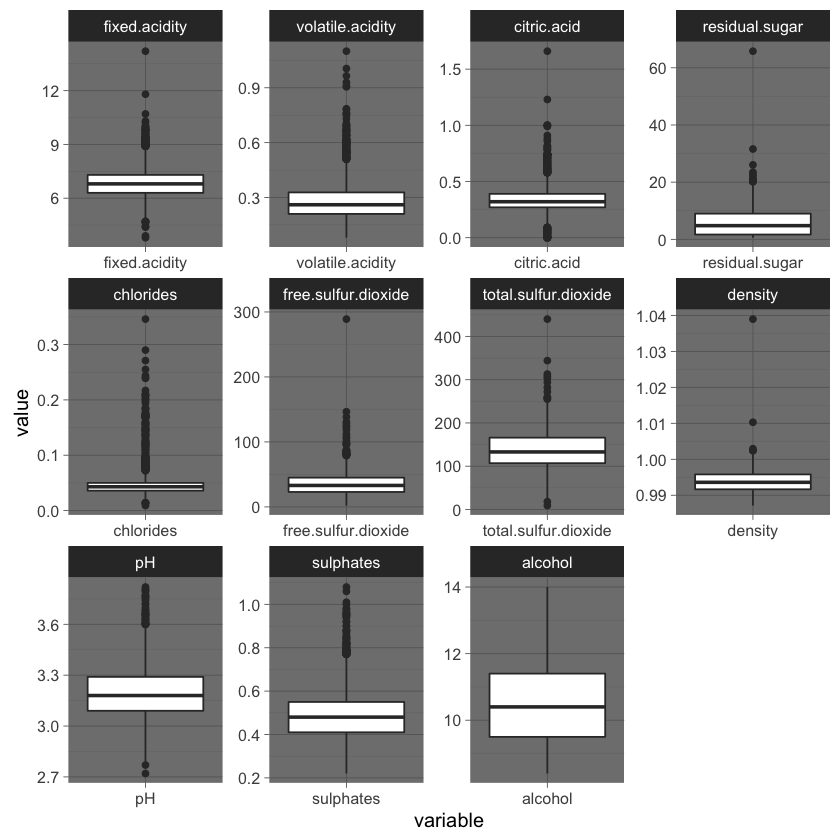

```r
bp <- ggplot(data = melt(wine[1:length(wine)-1]), aes( x = variable, y = value)) #creating distribution plot of all predictors
bp <- bp + facet_wrap(~variable, scales = 'free') + geom_boxplot() + theme_dark() #puting the plot in one window
bp
cat('\n\nBoxplot was split into seperate plots to better show the distribution')
```

### Distribution of all predictors

```
Skewness of the predictors
```

**total.sulfur.dioxide**

0.460396796765345

**alcohol**

0.464660908859115

**pH**

0.476317316042658

**fixed.acidity**

0.732582253055761

**sulphates**

0.948686675312572

**residual.sugar**

1.37880800591918

**density**

1.40571469744353

**citric.acid**

1.42266239238898

**volatile.acidity**

1.63918983369934

**free.sulfur.dioxide**

1.76917900074266

**chlorides**

4.92353845030257

```
Histogram
```

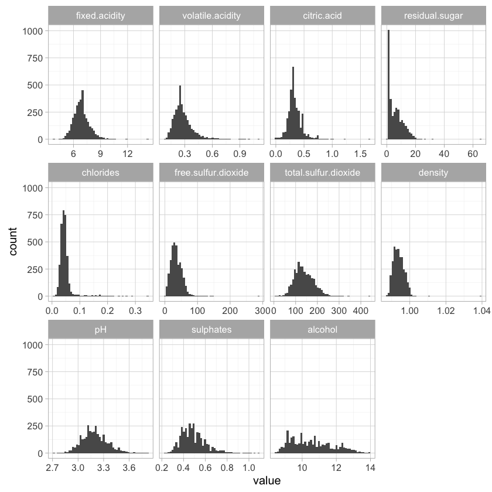

```r
face_dist <- ggplot(data = melt(wine[1:length(wine)-1]), mapping = aes(x = value)) +
                    geom_histogram(bins = 50) #creating distribution plot of all predictors
face_dist <- face_dist + facet_wrap(~variable, scales = 'free_x') + theme_light() #puting the plot in one window
cat('Skewness of the predictors')
sort(sapply(wine[1:length(wine)-1], skewness)) #perform skewness on all columns
cat('\nHistogram')
face_dist
```

#### Skewness

A sorted list of the skewness of the dataset is represented as shown above along with the distribution histogram. The data with a skewness closests to 0 represents a normal distribution and those that are positively further away are tend to be right skewed.

#### Discoveries from boxplot and histogram

Distribution type from http://asq.org/learn-about-quality/data-collection-analysis-tools/overview/histogram2.html

## Relationship between attributes

```
Scatterplot Matrix of all variables
```

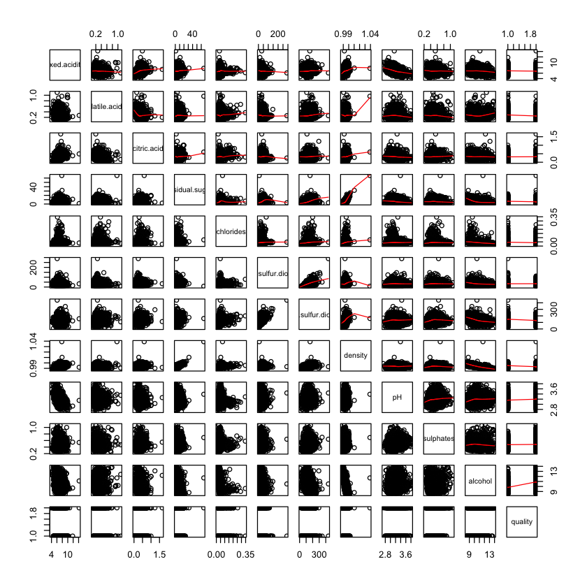

```r
cat('Scatterplot Matrix of all variables')
pairs(wine, upper.panel = panel.smooth) #produce scatterplot matrix
```

#### Summary of findings in relationship

- There are strong relationship between **density** and **residual sugar**, this makes sense as the solution residual of sugar increases the viscosity of wine
- Strong negative correlation between **density** and **alcohol**, this is reasonable as the more alcoholic the drink the less the density of the wine as the chemical compound for alcohol is saturated
- As **free sulfur dioxide** increaes it would contribute to the **total sulfur dioxide**, hence some correlation exists between them.
- There are also some correlation between **total sulfur dioxide** and **density**. The additional chemical composition of sulfur dioxide increases the density of the wine.

#### Function - Multivaraible scatterplot

```r
create_scatter <- function(dataset, Wine.Quality, xVar, yVar, xName, yName, title, lLim, ULim, lim) #setting formal parameter of function
    {
        #create scatter plot, uses wine quality as the third variable
        plot <- ggplot(data = dataset, aes(x = xVar, y = yVar)) + geom_point(aes(color = factor(Wine.Quality)))
        plot <- plot + xlab(xName) + ylab(yName) + ggtitle(title) #adds title and labels
        plot <- plot + scale_color_manual(values = c("blue", "purple")) #sets the colour of the factor
        plot <- plot + scale_x_continuous(breaks = seq(lLim, ULim, by = lim))
        plot <- plot + theme(axis.text.x=element_text(angle=90, hjust=1))
        return(plot)
}
```

```
Scatterplots of four differen multivariable
```

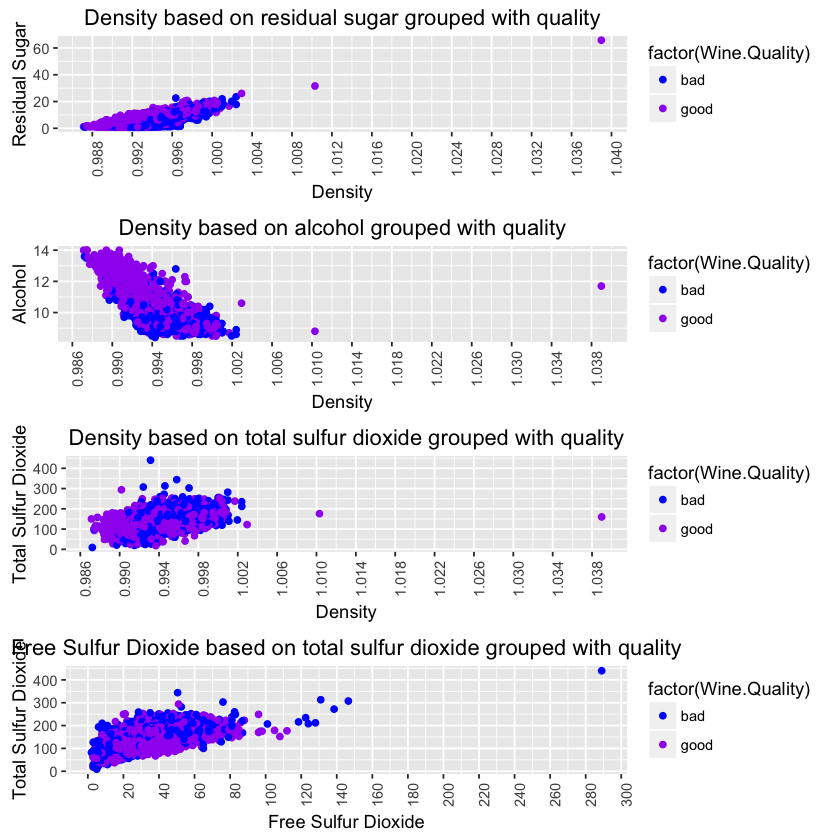

```r
denVressugar <- create_scatter(wine, wine$quality, wine$density, wine$residual.sugar, 'Density', 'Residual Sugar',
                               'Density based on residual sugar grouped with quality',
                               round(min(wine$density),2)-0.05, round(max(wine$density),2), 0.004)

denVAlcohol <- create_scatter(wine, wine$quality, wine$density, wine$alcohol, 'Density', 'Alcohol',
                               'Density based on alcohol grouped with quality', round(min(wine$density),2)-0.06,
                             round(max(wine$alcohol),2), 0.004)

denVsuldiox <- create_scatter(wine, wine$quality, wine$density, wine$total.sulfur.dioxide, 'Density', 'Total Sulfur Dioxide',
                               'Density based on total sulfur dioxide grouped with quality', round(min(wine$density),2)-0.06,
                             round(max(wine$total.sulfur.dioxide),2), 0.004)


freeSulfDioxVtot <- create_scatter(wine, wine$quality, wine$free.sulfur.dioxide, wine$total.sulfur.dioxide, 'Free Sulfur Dioxide',
                                   'Total Sulfur Dioxide', 'Free Sulfur Dioxide based on total sulfur dioxide grouped with quality',
                                  0, round(max(wine$total.sulfur.dioxide),2), 20)

cat('Scatterplots of four differen multivariable\n')
grid.arrange(denVressugar, denVAlcohol, denVsuldiox, freeSulfDioxVtot, nrow = 4)
```

#### Information based on the multivariable scatterplot:

> **Density and residual sugar** - Good quality wines are more abundant in the lower density range between 0.988 to 0.996 when compared to bad quality wines. Good quality wine are more distributed in the lower range with most of the residual sugar level being around 0 to 20. Extreme values are to do with good quality wines.

> **Density and alcohol** - Good quality wine are more distributed in the lower density range but higher level of alcohol and vice versa with the bad quality wine. Extreme value due to density are allocated to good quality wine, hence could be outliers.

> **Density and total sulfur dioxide** - Good quality wine are more distributed with lower density and lower total sulfur dioxide, between the ranges of 50 to 200. Extreme values of good wines are due to density, hence these could be outliers.

> **Free sulfur dioxide and total sulfur dioxide** - Good quality wines are more distributed with a lower total sulfur dioxide level and approximately 40-50 free sulfur dioxide. Extreme value is in respect to bad quality wine with high level of total sulfur dioxide and free sulfur dioxide.

**Summary:** Good quality wine tends to have a lower form of density but higher alcohol level. Nevertheless the total sulfur dioxide level and free sulfur dioxide is also within 50 to 200 and 10 to 50 respectively.

# Predicting the Probability of the Quality of Wine being Bad or Good

### Fitting the full model on the whole dataset

```r
null_model <- glm(quality ~ 1, data = wine, family = binomial) #creates a logistic regression on the whole dataset
full_model <- glm(quality ~., data = wine, family = binomial)
cat('Null model')
summary(null_model)
cat('\n\nFull model')
summary(full_model)
```

```
Null model
```

```
Call:
glm(formula = quality ~ 1, family = binomial, data = wine)

Deviance Residuals:
    Min       1Q   Median       3Q      Max
-1.4757  -1.4757   0.9059   0.9059   0.9059

Coefficients:
            Estimate Std. Error z value Pr(>|z|)
(Intercept)  0.67856    0.03693   18.37   <2e-16 ***
---
Signif. codes:  0 ‘***’ 0.001 ‘**’ 0.01 ‘*’ 0.05 ‘.’ 0.1 ‘ ’ 1

(Dispersion parameter for binomial family taken to be 1)

    Null deviance: 4194  on 3282  degrees of freedom
Residual deviance: 4194  on 3282  degrees of freedom
AIC: 4196

Number of Fisher Scoring iterations: 4
```

```
Full model
```

```
Call:
glm(formula = quality ~ ., family = binomial, data = wine)

Deviance Residuals:
    Min       1Q   Median       3Q      Max
-3.1121  -0.8539   0.4175   0.7762   2.4965

Coefficients:
                       Estimate Std. Error z value Pr(>|z|)
(Intercept)           1.458e+02  7.685e+01   1.897 0.057843 .
fixed.acidity        -7.231e-02  8.184e-02  -0.884 0.376928
volatile.acidity     -6.446e+00  5.073e-01 -12.706  < 2e-16 ***
citric.acid           3.542e-01  3.761e-01   0.942 0.346292
residual.sugar        1.180e-01  3.038e-02   3.882 0.000104 ***
chlorides            -5.128e-01  1.962e+00  -0.261 0.793807
free.sulfur.dioxide   1.103e-02  3.493e-03   3.158 0.001590 **
total.sulfur.dioxide -1.774e-03  1.507e-03  -1.178 0.238945
density              -1.588e+02  7.793e+01  -2.037 0.041621 *
pH                    1.168e+00  4.279e-01   2.729 0.006351 **
sulphates             1.960e+00  4.491e-01   4.365 1.27e-05 ***
alcohol               9.077e-01  1.048e-01   8.665  < 2e-16 ***
---
Signif. codes:  0 ‘***’ 0.001 ‘**’ 0.01 ‘*’ 0.05 ‘.’ 0.1 ‘ ’ 1

(Dispersion parameter for binomial family taken to be 1)

    Null deviance: 4194.0  on 3282  degrees of freedom
Residual deviance: 3227.2  on 3271  degrees of freedom
AIC: 3251.2

Number of Fisher Scoring iterations: 5
```

#### The use of logistic regression:

Logistic regression was used as it is able to classify binary style response varaible. Hence the probability of either bad or good using logistic regression is only between 0 and 1.

#### Summary of full mode:

> **Fixed Acidity**, **citric acid**, **chlorides** and **total suflur dioxide** - The absolute z value is rather small, hence the p-value is greater than 0.05. This indicates that these predictors should be excluded from the model in determining the probability of the wine being good or bad.

> The **Null deviance** at 4194, is the score of the goodness of the model in which only the intercept are included. It shows how well the quality of the wine was predicted by the model, including only the intercept, which is the grand mean. The variance based on this model would be low, however the model is highly bias and would produce significant test error.

> The **Residual deviance - Full Model**, the score of the model with all inputed predictors, is 3227.2, hence it is lower than the null deviance. This shows that the model with all the predictors explains the data better than the model with just the intercept. However the trade off is that the model is highly complexed. Although there is a reduce in bias from this, however the variance based on this model would be very high along with the test error.

### Anova test - Full model

```r
cat('ANOVA table of the model')
anova(full_model, test = "Chisq") #performs the anova
cat('\nChisq test of empty model and full model')
with(full_model, pchisq(null.deviance - deviance, df.null - df.residual, lower.tail = FALSE)) #calculates chisq test
```

```
ANOVA table of the model
```

|  | Df | Deviance | Resid. Df | Resid. Dev | Pr(>Chi) |
| --- | --- | --- | --- | --- | --- |
| NULL | NA | NA | 3282.000 | 4193.983 | NA |
| fixed.acidity | 1.000000e+00 | 3.434555e+01 | 3.281000e+03 | 4.159638e+03 | 4.614550e-09 |
| volatile.acidity | 1.000000e+00 | 1.865169e+02 | 3.280000e+03 | 3.973121e+03 | 1.830863e-42 |
| citric.acid | 1.000000e+00 | 4.380164e-02 | 3.279000e+03 | 3.973077e+03 | 8.342231e-01 |
| residual.sugar | 1.000000e+00 | 2.517025e+01 | 3.278000e+03 | 3.947907e+03 | 5.248572e-07 |
| chlorides | 1.000000e+00 | 1.155181e+02 | 3.277000e+03 | 3.832389e+03 | 6.060436e-27 |
| free.sulfur.dioxide | 1.000000e+00 | 5.627174e-02 | 3.276000e+03 | 3.832333e+03 | 8.124887e-01 |
| total.sulfur.dioxide | 1.000000e+00 | 5.927226e+01 | 3.275000e+03 | 3.773060e+03 | 1.372986e-14 |
| density | 1.000000e+00 | 3.314151e+02 | 3.274000e+03 | 3.441645e+03 | 4.727006e-74 |
| pH | 1.000000e+00 | 1.085417e+02 | 3.273000e+03 | 3.333104e+03 | 2.044983e-25 |
| sulphates | 1.000000e+00 | 4.494139e+01 | 3.272000e+03 | 3.288162e+03 | 2.030210e-11 |
| alcohol | 1.000000e+00 | 6.099122e+01 | 3.271000e+03 | 3.227171e+03 | 5.732979e-15 |

```
Chisq test of empty model and full model
```

2.65421366298592e-200

#### Analysis of the results:

**Anova Table**

The anova table shows the intial deviance using just the intercept, hence how the model is performing against the null model. As more predictors are added, in the order in which they appear in the dataset, the residual deviance becomes smaller. The table shows that all predictors are significant at 0.05 except for citric acid and free sulfur dioxide

**Chisq Test**

The p-value for the chi-square test is extremely small, smaller than its significant level at 0.05 hence the full_model is significantly better than the empty model

#### Function - Confusion matrix of the full model

```r
#function to create the confusion matrix of the prediction
confuse_matrix <- function(model, response) {
    pred <- predict(model, type = 'response') #predict using the
    pred_mod <- rep('bad', length(pred)) #assigns all prediction as bad
    pred_mod[pred > 0.5] <- 'good' #set all prediction greater than 0.5 to good - cutpoint
    table(pred_mod, response) #put values in a table
}
```

#### Function - Prediction accuracy

```r
correct_pred <- function(model, response, test_set){
    pred <- predict(model, type = 'response', test_set)
    pred_mod <- rep('bad', length(pred))
    pred_mod[pred > 0.5] <- 'good'
    result <- mean(pred_mod == response) #calculates the mean of all prediction that is reference to the quality
    return(result * 100) #returns the mean as a percentage to 2 decimal points
}
```

### Confusion matrix and the prediction accuracy of the trained model

```r
cat('Confusion matrix')
confuse_matrix(full_model, wine$quality)
cat('\nPercentage of correct prediction')
correct_pred(full_model, wine$quality, wine)
```

```
Confusion matrix
```

```
        response
pred_mod  bad good
    bad   608  282
    good  497 1896
```

```
Percentage of correct prediction
```

76.2717027109351

### Summary:

#### Explanation of the confusion matrix:

[output not shown]

Sensitivity and specificity is important to the prediction of binary value, the 'good' and 'bad' wines. In this case of sensitivity, the percentage of true defaulters, 'good' wines being identified is high at 87.05%. The specificity is identified as non-defaulters that are correctly identified, hence 'bad' wines identified as 'good', which is 55.02%. Hence, the logistic regression does a good job identifying the true defaulters, however does not do a great job at identifying 'bad' wines being 'good'

## Using step function to perform forward stepwise on the whole dataset

Previously the whole training dataset and predictors of wine was used to build a full model. However this model is highly bias as it contains all predictors of wine, although leading to a higher ressidual sum of squares, but this is an approach to determine how well the model fits the training data, but not the real world. Hence the model was most likely overfitting, favouring training error rather than test error. Cross validation using 10 folds will be used to reduce bias and variance of the model.

```r
#performs stepwise, forward selection basing it off a null model
mod1 <- step(null_model, scope = formula(full_model), direction = 'forward', k = 2, trace = FALSE)
mod2 <- step(null_model, scope = formula(full_model), direction = 'forward', k = log(nrow(wine)), trace = FALSE)
```

```r
cat('Model selection using forward stepwise and AIC')
mod1
cat('\n\nModel selection using forward stepwise and BIC')
mod2
```

```
Model selection using forward stepwise and AIC
```

```
Call:  glm(formula = quality ~ alcohol + volatile.acidity + residual.sugar +
    fixed.acidity + sulphates + free.sulfur.dioxide + pH + density,
    family = binomial, data = wine)

Coefficients:
        (Intercept)              alcohol     volatile.acidity
          1.595e+02            9.117e-01           -6.647e+00
     residual.sugar        fixed.acidity            sulphates
          1.223e-01           -5.689e-02            1.919e+00
free.sulfur.dioxide                   pH              density
          8.666e-03            1.141e+00           -1.726e+02

Degrees of Freedom: 3282 Total (i.e. Null);  3274 Residual
Null Deviance:	    4194
Residual Deviance: 3229 	AIC: 3247
```

```
Model selection using forward stepwise and BIC
```

```
Call:  glm(formula = quality ~ alcohol + volatile.acidity + residual.sugar +
    fixed.acidity + sulphates + free.sulfur.dioxide, family = binomial,
    data = wine)

Coefficients:
        (Intercept)              alcohol     volatile.acidity
          -8.943936             1.122666            -6.888461
     residual.sugar        fixed.acidity            sulphates
           0.054850            -0.228181             1.749092
free.sulfur.dioxide
           0.008893

Degrees of Freedom: 3282 Total (i.e. Null);  3276 Residual
Null Deviance:	    4194
Residual Deviance: 3238 	AIC: 3252
```

### Summary

#### Akaike Information Criterion (AIC) forward stepwise

Forward stepwise based model selection used AIC to determine which variable to include in the model by building the model up from a null model. AIC was used as a criteria to choose the optimal model. The forward stepwise chose eight predictors, ~alcohol + volatile acidity + residual sugar + fixed acidity + free sulfur dioxide + sulphates + density + pH.

#### Bayesian Information Criterion (BIC) forward stepwise

adjusting the k to log(n), changes the stepwise function to using BIC as the measurement. The predictors, ~ alcohol + volatile.acidity + residual.sugar + fixed.acidity + sulphates + free.sulfur.dioxide, were chosen by compairing the BIC and choosing amongst the model, the model with the lowest BIC, through the process of building the model by adding one variable at a time from a null model.

#### Analysis

The difference between the model selected by the AIC and BIC differs in the number of predictors used and the type of predictors. AIC differs from BIC as it had also used density and pH, hence consists of 8 predictors, whereas BIC only has 6 predictors. Both methods uses the concept of maximum likelihood estimates and penalizing the free parameters to combat overfitting, however both AIC and BIC produced different results in terms of final model due to the fact that the number of observation is large. BIC applies more penalty to complex models, causing BIC to produce a model with less predictors than AIC. The model from AIC will likely be more acceptable as BIC simply just reduces the maximum likelihood sleection due to the number of parameters being equal to the model's interest.

#### Using Cross validation

Although the number of predictors have been reduced along with the decrease in bias, but an increase in variance, cross validation using 10-folds will be used to support the selection of the variables that should be included in the final model. Using the whole data is highly bias towards the model selection. Using the cross validation then computing the predictive accuracy and AUC are better representation of the model's ability to predict a real world case, on an unseen data. Hence, in context it is the direct estimate of the test error, however in case of the logistic regression it is a representation of the prediction of the performance of the model's prediction.

## Building the predictive model using the forward stepwise approach

#### Function - K-fold Cross Validation

```r
#function to perform cross validation, allows the selection of which fold and the required data set
cv_set <- function(number_of_folds, fold_number, dataset, set_name){
    set.seed(1234)
    shuffled_data <- dataset[sample(nrow(dataset)),] #reshuffles the data
    folds <- rep_len(1:number_of_folds,nrow(shuffled_data)) #creates the fold on the shuffled data
    data_fold <- which(folds == fold_number) #subsets the data
    train_set <- shuffled_data[-data_fold,] #creating training set
    test_set <- shuffled_data[data_fold,] #creating test set
    if(set_name == "train"){ return(train_set)} #returns training set
    else if (set_name == "test"){return(test_set)} #returns the test set
}
```

#### Function - Area under curve

```r
auc_roc <- function(model, dataset, type){
    prediction_auc <- predict(model, newdata = dataset, type = 'response') #creates list of predictions on a dataset
    pred <- prediction(prediction_auc, dataset$quality)
    auc_plot <- performance(pred, measure = 'tpr', x.measure = 'fpr') #assigns specificity and sensitivity
    auc <- performance(pred, measure = 'auc')@y.values[[1]] #computes the AUC then convert to vector space
    if(type == 'auc'){return(auc)}
    else if(type == 'plot'){return(auc_plot)}
}
```

#### Function - Model Cross Validation

```r
#function to perform 10 cross validations on certain combination of response variable and the predictor/s
cross_model_10 <- function(response_n_predictors, type){
    pred_acc <- NULL #initiates a list
    auc <- NULL
    for(i in 1:10){ #10 folds
        train_set <- cv_set(10, i, wine, 'train') #calls the cross validation function, pulls out training set 1st fold
        test_set <- cv_set(10, i, wine, 'test')
        model <- glm(paste(response_n_predictors), data = train_set, family = binomial) #creates model based on input
        pred <- correct_pred(model, test_set$quality, test_set) #calls in the predictive accuracy function on the test
        auc_calc <- auc_roc(model, test_set, 'auc')
        auc <- c(auc, auc_calc)
        pred_acc <- c(pred_acc, pred) #appends the calculated prediction accuracy on the intiated list
    }
    if(type == "pa"){ return(mean(pred_acc))} #returns training set
    else if (type == "auc"){return((mean(auc)*100))} #returns the test set
}
```

#### Function - Model Selection Cross Validation

```r
#function to add a predictor to the inputed model and calculate the cross validation error (prediction accuracy)
model_selection_cv <- function(current_model, list_of_used_predictors, measurement){
    model_list <- NULL
    model_name <- NULL
    model_auc <- NULL
    flt_wine <- within(wine, rm(list=list_of_used_predictors)) #filters data on variables that was already used
    if(length(names(flt_wine)) > 0){ #process if there is still variables to be added
        for(i in 1:length(names(flt_wine))){ #iterates though the column names of the data
            temp_model <- paste(current_model, '+', names(flt_wine[i])) #adds in the one variable to the current
            model_name <- c(model_name, temp_model) #add model name to a list
            model_list <- c(model_list, cross_model_10(temp_model, 'pa')) #add the prediction accuracy to a list
            model_auc <- c(model_auc, cross_model_10(temp_model, 'auc')) #adds AUC to list
        }
        frame <- data.frame(model_name, model_list, model_auc) #puts the model name and prediction accuracy to a dataframe
        colnames(frame) <- c('Model', 'Prediction_Accuracy', 'AUC') #rename column of dataframe
        if(measurement == 'pa'){
            #prints out model with higher prediction accuracy
            print(as.character(frame$Model[frame$Prediction_Accuracy == max(frame$Prediction_Accuracy)]))
            print(paste('Predictive Accuracy: ',
                        frame$Prediction_Accuracy[frame$Prediction_Accuracy == max(frame$Prediction_Accuracy)]))
            frame
        } else if (measurement == 'auc') {
            print(as.character(frame$Model[frame$AUC == max(frame$AUC)])) #shows the model with highest AUC
            print(paste('AUC: ', frame$AUC[frame$AUC == max(frame$AUC)])) #prints AUC
            frame
        } else if (measurement == 'both') {
            print(as.character(frame$Model[(frame$Prediction_Accuracy == max(frame$Prediction_Accuracy)) &
                                           (frame$AUC == max(frame$AUC))]))
            print(paste('Predictive Accuracy: ',
            frame$Prediction_Accuracy[frame$Prediction_Accuracy == max(frame$Prediction_Accuracy)]))
            print(paste('AUC: ',  frame$AUC[frame$AUC == max(frame$AUC)]))
            frame
        }
    }else{print("You've already added all the features in")}
}
```

# Model selection using 10 folds cross validation

Two types of cross validation errors are used, predictive accuracy and AUC. Each variables will be added to the formula and the validation errors of each specific formula with the added variable will be cross validated on a 10 fold in which the error will be averaged. Each variables will be cross validated.

```r
cat('One Variable Model\n')
model_selection_cv('quality~', c('quality'), 'both')
cat('\nTwo Variables Model\n')
model_selection_cv('quality ~ + alcohol', c('quality', 'alcohol'), 'both')
cat('\nThree Variables Model\n')
model_selection_cv('quality ~ + alcohol + volatile.acidity', c('quality', 'alcohol', 'volatile.acidity'), 'both')
cat('\nFour Variables Model\n')
model_selection_cv('quality ~ + alcohol + volatile.acidity + residual.sugar',
                   c('quality', 'alcohol', 'volatile.acidity', 'residual.sugar'), 'both')
```

```
One Variable Model
[1] "quality~ + alcohol"
[1] "Predictive Accuracy:  71.5195715027059"
[1] "AUC:  75.5209568997625"
```

|  | Model | Prediction_Accuracy | AUC |
| --- | --- | --- | --- |
| 1 | quality~ + fixed.acidity | 66.4627659574468 | 55.1274333485307 |
| 2 | quality~ + volatile.acidity | 67.1327563199644 | 64.4767860861843 |
| 3 | quality~ + citric.acid | 66.3407220698347 | 48.2088606103212 |
| 4 | quality~ + residual.sugar | 66.2186781822225 | 55.2269877577666 |
| 5 | quality~ + chlorides | 67.315219808733 | 67.3102665059435 |
| 6 | quality~ + free.sulfur.dioxide | 66.3407220698347 | 48.2961392607217 |
| 7 | quality~ + total.sulfur.dioxide | 66.6456001186152 | 61.3284069141466 |
| 8 | quality~ + density | 66.6752539105938 | 69.5212058689324 |
| 9 | quality~ + pH | 66.2798391281785 | 56.9889465099004 |
| 10 | quality~ + sulphates | 66.3407220698347 | 52.6742960021081 |
| 11 | quality~ + alcohol | 71.5195715027059 | 75.5209568997625 |

```
Two Variables Model
[1] "quality ~ + alcohol + volatile.acidity"
[1] "Predictive Accuracy:  74.8699866557936"
[1] "AUC:  79.5716539670926"
```

|  | Model | Prediction_Accuracy | AUC |
| --- | --- | --- | --- |
| 1 | quality ~ + alcohol + fixed.acidity | 71.3373860182371 | 75.7744474425146 |
| 2 | quality ~ + alcohol + volatile.acidity | 74.8699866557936 | 79.5716539670926 |
| 3 | quality ~ + alcohol + citric.acid | 71.0628104381348 | 75.5613916674278 |
| 4 | quality ~ + alcohol + residual.sugar | 71.45831788865 | 75.8929694960575 |
| 5 | quality ~ + alcohol + chlorides | 71.7934984061087 | 75.6948096933864 |
| 6 | quality ~ + alcohol + free.sulfur.dioxide | 71.7623619245311 | 76.5538188152608 |
| 7 | quality ~ + alcohol + total.sulfur.dioxide | 71.4585032248499 | 75.4878860701492 |
| 8 | quality ~ + alcohol + density | 71.5803617762621 | 75.6401969440388 |
| 9 | quality ~ + alcohol + pH | 71.6718251908963 | 75.8951761739594 |
| 10 | quality ~ + alcohol + sulphates | 71.3676884869153 | 75.8953168707155 |

```
Three Variables Model
[1] "quality ~ + alcohol + volatile.acidity + residual.sugar"
[1] "Predictive Accuracy:  75.8148306027133"
[1] "AUC:  80.2671861820876"
```

|  | Model | Prediction_Accuracy | AUC |
| --- | --- | --- | --- |
| 1 | quality ~ + alcohol + volatile.acidity + fixed.acidity | 74.8090110460375 | 79.8943845110642 |
| 2 | quality ~ + alcohol + volatile.acidity + citric.acid | 74.7481281043814 | 79.5621865965372 |
| 3 | quality ~ + alcohol + volatile.acidity + residual.sugar | 75.8148306027133 | 80.2671861820876 |
| 4 | quality ~ + alcohol + volatile.acidity + chlorides | 74.7179183038031 | 79.5510044800288 |
| 5 | quality ~ + alcohol + volatile.acidity + free.sulfur.dioxide | 74.8995477796723 | 80.1115648423761 |
| 6 | quality ~ + alcohol + volatile.acidity + total.sulfur.dioxide | 74.7481281043814 | 79.6435372237702 |
| 7 | quality ~ + alcohol + volatile.acidity + density | 75.3574208614427 | 79.8849435346607 |
| 8 | quality ~ + alcohol + volatile.acidity + pH | 74.5045036696568 | 79.7366263668065 |
| 9 | quality ~ + alcohol + volatile.acidity + sulphates | 74.961172066128 | 79.85606448543 |

```
Four Variables Model
[1] "quality ~ + alcohol + volatile.acidity + residual.sugar + fixed.acidity"
[1] "Predictive Accuracy:  76.1501037882719"
[1] "AUC:  80.5757870847356"
```

|  | Model | Prediction_Accuracy | AUC |
| --- | --- | --- | --- |
| 1 | quality ~ + alcohol + volatile.acidity + residual.sugar + fixed.acidity | 76.1501037882719 | 80.5757870847356 |
| 2 | quality ~ + alcohol + volatile.acidity + residual.sugar + citric.acid | 75.8455037437912 | 80.2239780767691 |
| 3 | quality ~ + alcohol + volatile.acidity + residual.sugar + chlorides | 75.7232745199792 | 80.2427348236996 |
| 4 | quality ~ + alcohol + volatile.acidity + residual.sugar + free.sulfur.dioxide | 76.0578990288383 | 80.4895300738192 |
| 5 | quality ~ + alcohol + volatile.acidity + residual.sugar + total.sulfur.dioxide | 75.4491622803766 | 80.1618790372389 |
| 6 | quality ~ + alcohol + volatile.acidity + residual.sugar + density | 75.8147379346134 | 80.2874103306888 |
| 7 | quality ~ + alcohol + volatile.acidity + residual.sugar + pH | 76.0276892282601 | 80.4650313442832 |
| 8 | quality ~ + alcohol + volatile.acidity + residual.sugar + sulphates | 76.088850174216 | 80.5162259140057 |

### Based on Prediction Accuracy

```r
cat('\nGoing by Prediction Accuracy\n')
cat('\nFive Variables Model\n')
model_selection_cv('quality ~ + alcohol + volatile.acidity + residual.sugar + fixed.acidity',
                   c('quality', 'alcohol', 'volatile.acidity', 'residual.sugar', 'fixed.acidity'), 'pa')
cat('\nSix Variables Model\n')
model_selection_cv('quality ~ + alcohol + volatile.acidity + residual.sugar + fixed.acidity + citric.acid',
                   c('quality', 'alcohol', 'volatile.acidity', 'residual.sugar', 'fixed.acidity', 'citric.acid'), 'pa')
cat('\nSeven Variables Model\n')
model_selection_cv('quality ~ + alcohol + volatile.acidity + residual.sugar + fixed.acidity + citric.acid + density',
                   c('quality', 'alcohol', 'volatile.acidity', 'residual.sugar', 'fixed.acidity', 'citric.acid', 'density'), 'pa')
cat('\nEight Variables Model\n')
model_selection_cv('quality ~ + alcohol + volatile.acidity + residual.sugar + fixed.acidity +
                    citric.acid + density + chlorides',
                   c('quality', 'alcohol', 'volatile.acidity', 'residual.sugar',
                     'fixed.acidity', 'citric.acid', 'density', 'chlorides'), 'pa')
cat('\nNine Variables Model\n')
model_selection_cv('quality ~ + alcohol + volatile.acidity + residual.sugar + fixed.acidity +
                    citric.acid + density + total.sulfur.dioxide + chlorides + total.sulfur.dioxide',
                   c('quality', 'alcohol', 'volatile.acidity', 'residual.sugar',
                     'fixed.acidity', 'citric.acid', 'density', 'chlorides', 'total.sulfur.dioxide'), 'pa')
cat('\nTen Variable Model\n')
model_selection_cv('quality ~ + alcohol + volatile.acidity + residual.sugar + fixed.acidity +
                    citric.acid + density + total.sulfur.dioxide + chlorides + total.sulfur.dioxide + pH',
                   c('quality', 'alcohol', 'volatile.acidity', 'residual.sugar',
                     'fixed.acidity', 'citric.acid', 'density', 'chlorides', 'total.sulfur.dioxide', 'pH'), 'pa')
cat('\nFull Model\n')
cat('\nEleven Variable Model\n')
model_selection_cv('quality ~ + alcohol + volatile.acidity + residual.sugar + fixed.acidity +
                    citric.acid + density + total.sulfur.dioxide + chlorides + pH + free.sulfur.dioxide',
                   c('quality', 'alcohol', 'volatile.acidity', 'residual.sugar',
                     'fixed.acidity', 'citric.acid', 'density', 'total.sulfur.dioxide', 'chlorides', 'pH', 'free.sulfur.dioxide'), 'pa')
```

```
Going by Prediction Accuracy

Five Variables Model
[1] "quality ~ + alcohol + volatile.acidity + residual.sugar + fixed.acidity + citric.acid"
[1] "Predictive Accuracy:  76.2717770034843"
```

|  | Model | Prediction_Accuracy | AUC |
| --- | --- | --- | --- |
| 1 | quality ~ + alcohol + volatile.acidity + residual.sugar + fixed.acidity + citric.acid | 76.2717770034843 | 80.577894891484 |
| 2 | quality ~ + alcohol + volatile.acidity + residual.sugar + fixed.acidity + chlorides | 76.211079398028 | 80.5452856513898 |
| 3 | quality ~ + alcohol + volatile.acidity + residual.sugar + fixed.acidity + free.sulfur.dioxide | 75.9050893320483 | 80.6852011913151 |
| 4 | quality ~ + alcohol + volatile.acidity + residual.sugar + fixed.acidity + total.sulfur.dioxide | 75.9059233449477 | 80.4904171041827 |
| 5 | quality ~ + alcohol + volatile.acidity + residual.sugar + fixed.acidity + density | 76.1196159833939 | 80.545426295337 |
| 6 | quality ~ + alcohol + volatile.acidity + residual.sugar + fixed.acidity + pH | 76.0589183779376 | 80.6188393041484 |
| 7 | quality ~ + alcohol + volatile.acidity + residual.sugar + fixed.acidity + sulphates | 76.1494551115724 | 80.8403521069528 |

```
Six Variables Model
[1] "quality ~ + alcohol + volatile.acidity + residual.sugar + fixed.acidity + citric.acid + density"
[1] "Predictive Accuracy:  76.2109867299281"
```

|  | Model | Prediction_Accuracy | AUC |
| --- | --- | --- | --- |
| 1 | quality ~ + alcohol + volatile.acidity + residual.sugar + fixed.acidity + citric.acid + chlorides | 76.18059159315 | 80.5251706053204 |
| 2 | quality ~ + alcohol + volatile.acidity + residual.sugar + fixed.acidity + citric.acid + free.sulfur.dioxide | 75.844484394692 | 80.6843879310106 |
| 3 | quality ~ + alcohol + volatile.acidity + residual.sugar + fixed.acidity + citric.acid + total.sulfur.dioxide | 75.9058306768478 | 80.4762827194272 |
| 4 | quality ~ + alcohol + volatile.acidity + residual.sugar + fixed.acidity + citric.acid + density | 76.2109867299281 | 80.5584796134899 |
| 5 | quality ~ + alcohol + volatile.acidity + residual.sugar + fixed.acidity + citric.acid + pH | 76.1195233152939 | 80.6248658526597 |
| 6 | quality ~ + alcohol + volatile.acidity + residual.sugar + fixed.acidity + citric.acid + sulphates | 75.9365038179257 | 80.8167623950137 |

```
Seven Variables Model
[1] "quality ~ + alcohol + volatile.acidity + residual.sugar + fixed.acidity + citric.acid + density + chlorides"
[1] "Predictive Accuracy:  76.1499184520721"
```

|  | Model | Prediction_Accuracy | AUC |
| --- | --- | --- | --- |
| 1 | quality ~ + alcohol + volatile.acidity + residual.sugar + fixed.acidity + citric.acid + density + chlorides | 76.1499184520721 | 80.5126301141308 |
| 2 | quality ~ + alcohol + volatile.acidity + residual.sugar + fixed.acidity + citric.acid + density + free.sulfur.dioxide | 75.9359478093261 | 80.6866367654354 |
| 3 | quality ~ + alcohol + volatile.acidity + residual.sugar + fixed.acidity + citric.acid + density + total.sulfur.dioxide | 75.9364111498258 | 80.4554023289445 |
| 4 | quality ~ + alcohol + volatile.acidity + residual.sugar + fixed.acidity + citric.acid + density + pH | 75.9061086811476 | 80.6202723969643 |
| 5 | quality ~ + alcohol + volatile.acidity + residual.sugar + fixed.acidity + citric.acid + density + sulphates | 75.6318111053451 | 80.7986521675635 |

```
Eight Variables Model
[1] "quality ~ + alcohol + volatile.acidity + residual.sugar + fixed.acidity + \n                    citric.acid + density + chlorides + total.sulfur.dioxide"
[1] "Predictive Accuracy:  75.9363184817258"
```

|  | Model | Prediction_Accuracy | AUC |
| --- | --- | --- | --- |
| 1 | quality ~ + alcohol + volatile.acidity + residual.sugar + fixed.acidity + citric.acid + density + chlorides + free.sulfur.dioxide | 75.6920453703017 | 80.6612377125995 |
| 2 | quality ~ + alcohol + volatile.acidity + residual.sugar + fixed.acidity + citric.acid + density + chlorides + total.sulfur.dioxide | 75.9363184817258 | 80.43335430119 |
| 3 | quality ~ + alcohol + volatile.acidity + residual.sugar + fixed.acidity + citric.acid + density + chlorides + pH | 75.7844354659352 | 80.6037884357459 |
| 4 | quality ~ + alcohol + volatile.acidity + residual.sugar + fixed.acidity + citric.acid + density + chlorides + sulphates | 75.5403476907109 | 80.7737385090213 |

```
Nine Variables Model
[1] "quality ~ + alcohol + volatile.acidity + residual.sugar + fixed.acidity + \n                    citric.acid + density + total.sulfur.dioxide + chlorides + total.sulfur.dioxide + pH"
[1] "Predictive Accuracy:  75.662484246423"
```

|  | Model | Prediction_Accuracy | AUC |
| --- | --- | --- | --- |
| 1 | quality ~ + alcohol + volatile.acidity + residual.sugar + fixed.acidity + citric.acid + density + total.sulfur.dioxide + chlorides + total.sulfur.dioxide + free.sulfur.dioxide | 75.4792794128549 | 80.5934468665429 |
| 2 | quality ~ + alcohol + volatile.acidity + residual.sugar + fixed.acidity + citric.acid + density + total.sulfur.dioxide + chlorides + total.sulfur.dioxide + pH | 75.662484246423 | 80.5294576176822 |
| 3 | quality ~ + alcohol + volatile.acidity + residual.sugar + fixed.acidity + citric.acid + density + total.sulfur.dioxide + chlorides + total.sulfur.dioxide + sulphates | 75.3878159982208 | 80.7090633933754 |

```
Ten Variable Model
[1] "quality ~ + alcohol + volatile.acidity + residual.sugar + fixed.acidity + \n                    citric.acid + density + total.sulfur.dioxide + chlorides + total.sulfur.dioxide + pH + free.sulfur.dioxide"
[1] "Predictive Accuracy:  75.7229038475795"
```

|  | Model | Prediction_Accuracy | AUC |
| --- | --- | --- | --- |
| 1 | quality ~ + alcohol + volatile.acidity + residual.sugar + fixed.acidity + citric.acid + density + total.sulfur.dioxide + chlorides + total.sulfur.dioxide + pH + free.sulfur.dioxide | 75.7229038475795 | 80.6851246035296 |
| 2 | quality ~ + alcohol + volatile.acidity + residual.sugar + fixed.acidity + citric.acid + density + total.sulfur.dioxide + chlorides + total.sulfur.dioxide + pH + sulphates | 75.6012306323671 | 80.8064382886634 |

```
Full Model

Eleven Variable Model
[1] "quality ~ + alcohol + volatile.acidity + residual.sugar + fixed.acidity + \n                    citric.acid + density + total.sulfur.dioxide + chlorides + pH + free.sulfur.dioxide + sulphates"
[1] "Predictive Accuracy:  75.6010452961672"
```

|  | Model | Prediction_Accuracy | AUC |
| --- | --- | --- | --- |
| 1 | quality ~ + alcohol + volatile.acidity + residual.sugar + fixed.acidity + citric.acid + density + total.sulfur.dioxide + chlorides + pH + free.sulfur.dioxide + sulphates | 75.6010452961672 | 81.013796997549 |

### Based on AUC

```r
cat('\nGoing by Prediction Accuracy\n')
cat('\nFive Variables Model\n')
model_selection_cv('quality ~ + alcohol + volatile.acidity + residual.sugar + fixed.acidity',
                   c('quality', 'alcohol', 'volatile.acidity', 'residual.sugar', 'fixed.acidity'), 'auc')

cat('\nSix Variables Model\n')
model_selection_cv('quality ~ + alcohol + volatile.acidity + residual.sugar + fixed.acidity + sulphates',
                   c('quality', 'alcohol', 'volatile.acidity', 'residual.sugar', 'fixed.acidity', 'sulphates'), 'auc')

cat('\nSeven Variables Model\n')
model_selection_cv('quality ~ + alcohol + volatile.acidity +
                    residual.sugar + fixed.acidity + sulphates + free.sulfur.dioxide',
                   c('quality', 'alcohol', 'volatile.acidity',
                     'residual.sugar', 'fixed.acidity', 'sulphates', 'free.sulfur.dioxide'), 'auc')

cat('\nEight Variables Model\n')
model_selection_cv('quality ~ + alcohol + volatile.acidity + residual.sugar +
                    fixed.acidity + sulphates + free.sulfur.dioxide + density',
                   c('quality', 'alcohol', 'volatile.acidity', 'residual.sugar',
                     'fixed.acidity', 'sulphates', 'free.sulfur.dioxide', 'density'), 'auc')

cat('\nNine Variables Model\n')
model_selection_cv('quality ~ + alcohol + volatile.acidity + residual.sugar +
                    fixed.acidity + sulphates + free.sulfur.dioxide + density + pH',
                   c('quality', 'alcohol', 'volatile.acidity', 'residual.sugar',
                     'fixed.acidity', 'sulphates', 'free.sulfur.dioxide', 'density', 'pH'), 'auc')

cat('\nTen Variables Model\n')
model_selection_cv('quality ~ + alcohol + volatile.acidity + residual.sugar +
                    fixed.acidity + sulphates + free.sulfur.dioxide + density + pH + citric.acid',
                   c('quality', 'alcohol', 'volatile.acidity', 'residual.sugar',
                     'fixed.acidity', 'sulphates', 'free.sulfur.dioxide', 'density', 'pH', 'citric.acid'), 'auc')

cat('\nFull Model\n')
cat('\nEleven Variables Model\n')
model_selection_cv('quality ~ + alcohol + volatile.acidity + residual.sugar +
                    fixed.acidity + sulphates + free.sulfur.dioxide + density +
                    pH + citric.acid + chlorides',
                   c('quality', 'alcohol', 'volatile.acidity', 'residual.sugar',
                     'fixed.acidity', 'sulphates', 'free.sulfur.dioxide', 'density',
                     'pH', 'citric.acid', 'chlorides'), 'auc')
```

```
Going by Prediction Accuracy

Five Variables Model
[1] "quality ~ + alcohol + volatile.acidity + residual.sugar + fixed.acidity + sulphates"
[1] "AUC:  80.8403521069528"
```

|  | Model | Prediction_Accuracy | AUC |
| --- | --- | --- | --- |
| 1 | quality ~ + alcohol + volatile.acidity + residual.sugar + fixed.acidity + citric.acid | 76.2717770034843 | 80.577894891484 |
| 2 | quality ~ + alcohol + volatile.acidity + residual.sugar + fixed.acidity + chlorides | 76.211079398028 | 80.5452856513898 |
| 3 | quality ~ + alcohol + volatile.acidity + residual.sugar + fixed.acidity + free.sulfur.dioxide | 75.9050893320483 | 80.6852011913151 |
| 4 | quality ~ + alcohol + volatile.acidity + residual.sugar + fixed.acidity + total.sulfur.dioxide | 75.9059233449477 | 80.4904171041827 |
| 5 | quality ~ + alcohol + volatile.acidity + residual.sugar + fixed.acidity + density | 76.1196159833939 | 80.545426295337 |
| 6 | quality ~ + alcohol + volatile.acidity + residual.sugar + fixed.acidity + pH | 76.0589183779376 | 80.6188393041484 |
| 7 | quality ~ + alcohol + volatile.acidity + residual.sugar + fixed.acidity + sulphates | 76.1494551115724 | 80.8403521069528 |

```
Six Variables Model
[1] "quality ~ + alcohol + volatile.acidity + residual.sugar + fixed.acidity + sulphates + free.sulfur.dioxide"
[1] "AUC:  80.9829868694376"
```

|  | Model | Prediction_Accuracy | AUC |
| --- | --- | --- | --- |
| 1 | quality ~ + alcohol + volatile.acidity + residual.sugar + fixed.acidity + sulphates + citric.acid | 75.9365038179257 | 80.8167623950137 |
| 2 | quality ~ + alcohol + volatile.acidity + residual.sugar + fixed.acidity + sulphates + chlorides | 75.997201423382 | 80.8311772972757 |
| 3 | quality ~ + alcohol + volatile.acidity + residual.sugar + fixed.acidity + sulphates + free.sulfur.dioxide | 75.7228111794796 | 80.9829868694376 |
| 4 | quality ~ + alcohol + volatile.acidity + residual.sugar + fixed.acidity + sulphates + total.sulfur.dioxide | 75.7840647935355 | 80.7568977096674 |
| 5 | quality ~ + alcohol + volatile.acidity + residual.sugar + fixed.acidity + sulphates + density | 75.9363184817258 | 80.80141050296 |
| 6 | quality ~ + alcohol + volatile.acidity + residual.sugar + fixed.acidity + sulphates + pH | 75.9669916228038 | 80.8427581875624 |

```
Seven Variables Model
[1] "quality ~ + alcohol + volatile.acidity + \n                    residual.sugar + fixed.acidity + sulphates + free.sulfur.dioxide + density"
[1] "AUC:  80.9898143791259"
```

|  | Model | Prediction_Accuracy | AUC |
| --- | --- | --- | --- |
| 1 | quality ~ + alcohol + volatile.acidity + residual.sugar + fixed.acidity + sulphates + free.sulfur.dioxide + citric.acid | 75.6619282378234 | 80.966094157999 |
| 2 | quality ~ + alcohol + volatile.acidity + residual.sugar + fixed.acidity + sulphates + free.sulfur.dioxide + chlorides | 75.6314404329454 | 80.9518149856004 |
| 3 | quality ~ + alcohol + volatile.acidity + residual.sugar + fixed.acidity + sulphates + free.sulfur.dioxide + total.sulfur.dioxide | 75.8755282081696 | 80.9502133351837 |
| 4 | quality ~ + alcohol + volatile.acidity + residual.sugar + fixed.acidity + sulphates + free.sulfur.dioxide + density | 75.4792794128549 | 80.9898143791259 |
| 5 | quality ~ + alcohol + volatile.acidity + residual.sugar + fixed.acidity + sulphates + free.sulfur.dioxide + pH | 75.7536696567574 | 80.9687711516255 |

```
Eight Variables Model
[1] "quality ~ + alcohol + volatile.acidity + residual.sugar + \n                    fixed.acidity + sulphates + free.sulfur.dioxide + density + pH"
[1] "AUC:  81.1060929792823"
```

|  | Model | Prediction_Accuracy | AUC |
| --- | --- | --- | --- |
| 1 | quality ~ + alcohol + volatile.acidity + residual.sugar + fixed.acidity + sulphates + free.sulfur.dioxide + density + citric.acid | 75.5403476907109 | 80.9575364034439 |
| 2 | quality ~ + alcohol + volatile.acidity + residual.sugar + fixed.acidity + sulphates + free.sulfur.dioxide + density + chlorides | 75.418118466899 | 80.9634467150947 |
| 3 | quality ~ + alcohol + volatile.acidity + residual.sugar + fixed.acidity + sulphates + free.sulfur.dioxide + density + total.sulfur.dioxide | 75.8146452665135 | 80.9041245012748 |
| 4 | quality ~ + alcohol + volatile.acidity + residual.sugar + fixed.acidity + sulphates + free.sulfur.dioxide + density + pH | 75.8138112536141 | 81.1060929792823 |

```
Nine Variables Model
[1] "quality ~ + alcohol + volatile.acidity + residual.sugar + \n                    fixed.acidity + sulphates + free.sulfur.dioxide + density + pH + citric.acid"
[1] "AUC:  81.0909557430345"
```

|  | Model | Prediction_Accuracy | AUC |
| --- | --- | --- | --- |
| 1 | quality ~ + alcohol + volatile.acidity + residual.sugar + fixed.acidity + sulphates + free.sulfur.dioxide + density + pH + citric.acid | 75.6922307065016 | 81.0909557430345 |
| 2 | quality ~ + alcohol + volatile.acidity + residual.sugar + fixed.acidity + sulphates + free.sulfur.dioxide + density + pH + chlorides | 75.752835643858 | 81.0833623976867 |
| 3 | quality ~ + alcohol + volatile.acidity + residual.sugar + fixed.acidity + sulphates + free.sulfur.dioxide + density + pH + total.sulfur.dioxide | 75.966713618504 | 81.0531241532126 |

```
Ten Variables Model
[1] "quality ~ + alcohol + volatile.acidity + residual.sugar + \n                    fixed.acidity + sulphates + free.sulfur.dioxide + density + pH + citric.acid + chlorides"
[1] "AUC:  81.0684950393917"
```

|  | Model | Prediction_Accuracy | AUC |
| --- | --- | --- | --- |
| 1 | quality ~ + alcohol + volatile.acidity + residual.sugar + fixed.acidity + sulphates + free.sulfur.dioxide + density + pH + citric.acid + chlorides | 75.6310697605456 | 81.0684950393917 |
| 2 | quality ~ + alcohol + volatile.acidity + residual.sugar + fixed.acidity + sulphates + free.sulfur.dioxide + density + pH + citric.acid + total.sulfur.dioxide | 75.6622062421232 | 81.0299850006865 |

```
Full Model

Eleven Variables Model
[1] "quality ~ + alcohol + volatile.acidity + residual.sugar + \n                    fixed.acidity + sulphates + free.sulfur.dioxide + density + \n                    pH + citric.acid + chlorides + total.sulfur.dioxide"
[1] "AUC:  81.013796997549"
```

|  | Model | Prediction_Accuracy | AUC |
| --- | --- | --- | --- |
| 1 | quality ~ + alcohol + volatile.acidity + residual.sugar + fixed.acidity + sulphates + free.sulfur.dioxide + density + pH + citric.acid + chlorides + total.sulfur.dioxide | 75.6010452961672 | 81.013796997549 |

### Prediction accuracy dataframe

```r
num_model_var <- c(1:11)
pred_ac_list <- c(71.5195715027059,74.8699866557936,75.8148306027133,76.1501037882719,76.2717770034843,76.2109867299281,
                 76.1499184520721,75.9363184817258,75.662484246423,75.7229038475795,75.6010452961672)
auc_list <- c(75.5209568997625,79.5716539670926,80.2671861820876,80.5757870847356,80.8403521069528,
             80.9829868694376,80.9898143791259,81.1060929792823,81.0909557430345,81.0684950393917,81.013796997549)
pred_ac_df <- data.frame(num_model_var, pred_ac_list, auc_list) #creates list of concatenated values
pred_ac_df
```

|  | num_model_var | pred_ac_list | auc_list |
| --- | --- | --- | --- |
| 1 | 1.00000 | 71.51957 | 75.52096 |
| 2 | 2.00000 | 74.86999 | 79.57165 |
| 3 | 3.00000 | 75.81483 | 80.26719 |
| 4 | 4.00000 | 76.15010 | 80.57579 |
| 5 | 5.00000 | 76.27178 | 80.84035 |
| 6 | 6.00000 | 76.21099 | 80.98299 |
| 7 | 7.00000 | 76.14992 | 80.98981 |
| 8 | 8.00000 | 75.93632 | 81.10609 |
| 9 | 9.00000 | 75.66248 | 81.09096 |
| 10 | 10.0000 | 75.7229 | 81.0685 |
| 11 | 11.00000 | 75.60105 | 81.01380 |

### Cross validation error plot

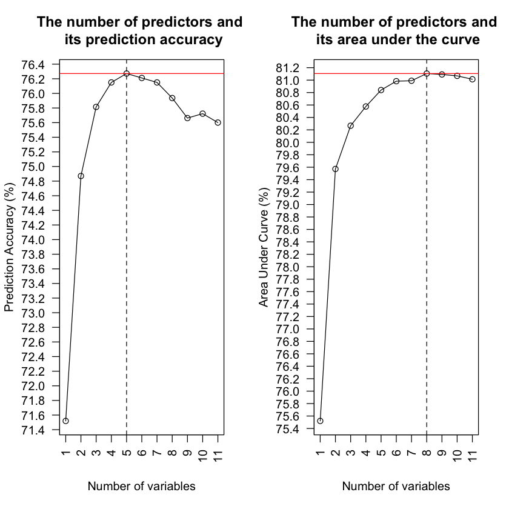

```r
par(mfrow = c(1,2))
plot(pred_ac_df$num_model_var, pred_ac_df$pred_ac_list, type = 'o', xlab = 'Number of variables',
     ylab = 'Prediction Accuracy (%)', yaxt = 'n', xaxt = 'n') #plotting PA against num variables, connect them
axis(2, at = seq(70, 77, by = .2), las=2) # reassigns the ticks
axis(1, at = seq(1, 11, by = 1), las=2)
abline(h = max(pred_ac_list), v = 0, col = "red") #adds in red line
abline(v = 5, lty = 20)
title('The number of predictors and \n its prediction accuracy')

plot(pred_ac_df$num_model_var, pred_ac_df$auc_list, type = 'o', xlab = 'Number of variables',
     ylab = 'Area Under Curve (%)', yaxt = 'n', xaxt = 'n')
axis(2, at = seq(75, 82, by = .2), las=2)
axis(1, at = seq(1, 11, by = 1), las=2)
abline(h = max(pred_ac_df$auc_list), v = 0, col = "red")
abline(v = 8, lty = 20)
title('The number of predictors and \n its area under the curve')
```

### One Standard Error Rule

```r
standard_error <- function(lists){sd(lists)/sqrt(length(lists))} # function to calc standard error
cat('One standard error rule predictive Accuracy:')
cat('\nmax = ', max(pred_ac_df$pred_ac_list))
cat('\nStandard error = ', standard_error(pred_ac_df$pred_ac_list))
cat('\nBelow is the list of predictive accuracy that fall between the one-standard-error range:')
pred_ac_df$pred_ac_list[pred_ac_df$pred_ac_list >= (max(pred_ac_df$pred_ac_list) - standard_error(pred_ac_df$pred_ac_list))
                       & pred_ac_df$pred_ac_list <= max(pred_ac_df$pred_ac_list)] #determines 1se away from highest pa

cat('\nOne standard error rule AUC:')
cat('\nmean = ', max(pred_ac_df$auc_list))
cat('\nStandard error = ', standard_error(pred_ac_df$auc_list))
cat('\nBelow is the list of predictive accuracy that fall between the one-standard-error range:')
pred_ac_df$auc_list[pred_ac_df$auc_list >= (max(pred_ac_df$auc_list) - standard_error(pred_ac_df$auc_list))
                   & pred_ac_df$auc_list <= max(pred_ac_df$auc_list)] #determines 1se away from highest auc
```

```
One standard error rule predictive Accuracy:
max =  76.27178
Standard error =  0.4104436
Below is the list of predictive accuracy that fall between the one-standard-error range:
```

1. 76.1501037882719

2. 76.2717770034843

3. 76.2109867299281

4. 76.1499184520721

5. 75.9363184817258

```
One standard error rule AUC:
mean =  81.10609
Standard error =  0.4958916
Below is the list of predictive accuracy that fall between the one-standard-error range:
```

1. 80.8403521069528

2. 80.9829868694376

3. 80.9898143791259

4. 81.1060929792823

5. 81.0909557430345

6. 81.0684950393917

7. 81.013796997549

## Summary of result:

#### Seed

The seed was set to be 1234 in the cross validation, this ensured that the result produced would be the same if it were to be reproduced. By changing or removing the seed the result shown would vary, but only slightly.

#### Models selected and their predictive accuracy

| Model Number | # Predictors | Predictive Accuracy (%) | AUC (%) |
| --- | --- | --- | --- |
| quality ~ alcohol | 1 | 71.52 | 75.52 |
| quality ~ alcohol + volatile.acidity | 2 | 74.87 | 79.57 |
| quality ~ alcohol + volatile.acidity + residual.sugar | 3 | 75.81 | 80.27 |
| quality ~ alcohol + volatile.acidity + residual.sugar + fixed.acidity | 4 | 76.15 | 80.58 |

#### Models selected after using just predictive accuracy

| Model Number | # Predictors | Predictive Accuracy (%) | AUC (%) |
| --- | --- | --- | --- |
| quality ~ alcohol + volatile.acidity + residual.sugar + fixed.acidity + citric.acid | 5 | 76.27 | 80.58 |
| quality ~ alcohol + volatile.acidity + residual.sugar + fixed.acidity + citric.acid + density | 6 | 76.21 | 80.56 |
| quality ~ alcohol + volatile.acidity + residual.sugar + fixed.acidity + citric.acid + density + chlorides | 7 | 76.15 | 80.51 |
| quality ~ alcohol + volatile.acidity + residual.sugar + fixed.acidity + citric.acid + density + chlorides + total.sulfur.dioxide | 8 | 75.93 | 80.43 |
| quality ~ alcohol + volatile.acidity + residual.sugar + fixed.acidity + citric.acid + density + total.sulfur.dioxide + chlorides + total.sulfur.dioxide + pH | 9 | 75.66 | 80.59 |
| quality ~ alcohol + volatile.acidity + residual.sugar + fixed.acidity + citric.acid + density + total.sulfur.dioxide + chlorides + total.sulfur.dioxide + pH + free.sulfur.dioxide | 10 | 75.72 | 80.69 |
| quality ~ alcohol + volatile.acidity + residual.sugar + fixed.acidity + citric.acid + density + total.sulfur.dioxide + chlorides + pH + free.sulfur.dioxide + sulphates | 11 | 75.60 | 81.01 |

#### Models selected after using just AUC

| Model Number | # Predictors | Predictive Accuracy (%) | AUC (%) |
| --- | --- | --- | --- |
| quality ~ alcohol + volatile.acidity + residual.sugar + fixed.acidity + sulphates | 5 | 76.15 | 80.84 |
| quality ~ alcohol + volatile.acidity + residual.sugar + fixed.acidity + sulphates + free.sulfur.dioxide | 6 | 75.72 | 80.98 |
| quality ~ alcohol + volatile.acidity + residual.sugar + fixed.acidity + sulphates + free.sulfur.dioxide + density | 7 | 75.48 | 80.99 |
| quality ~ alcohol + volatile.acidity + residual.sugar + fixed.acidity + sulphates + free.sulfur.dioxide + density + pH | 8 | 75.81 | 81.11 |
| quality ~ alcohol + volatile.acidity + residual.sugar + fixed.acidity + sulphates + free.sulfur.dioxide + density + pH + citric.acid | 9 | 75.69 | 81.09 |
| quality ~ alcohol + volatile.acidity + residual.sugar + fixed.acidity + sulphates + free.sulfur.dioxide + density + pH + citric.acid + chlorides | 10 | 75.63 | 81.07 |
| quality ~ alcohol + volatile.acidity + residual.sugar + fixed.acidity + sulphates + free.sulfur.dioxide + density + pH + citric.acid + chlorides + total.sulfur.dioxide | 11 | 75.60 | 81.01 |

### Descriptions:

The process of selecting a final model was aided through 10-folds cross validation using the forward stepwise approach. All of the variables was added to the base model each time, and 10-folds cross validation was applied to produce a mean prediction accuracy/AUC, values allocating to certain variable is added to the model. Process repeats until the null model becomes a full model.

#### Best model using predictive accuracy

> **quality ~ alcohol + volatile.acidity + residual.sugar + fixed.acidity + citric.acid**

#### Best model using AUC

As shown in the plot based, the AUC tends to increase as more variables are added. However as the complexity of the model increases passes the point where 8 predictors were used, it starts to slightly decrease. It is necessarily to use the *one-standard-error-rule*. As the AUC for each models seemed closely related. The model with a size of 5 has an AUC within 1 standard error of the highest AUC, which is based on the 8 predictor model. Hence, the model with 5 predictors will be used as the final model from AUC.

> **quality ~ alcohol + volatile.acidity + residual.sugar + fixed.acidity + sulphates**

#### Selecting final model

Although the measurement of predictive accuracy is more intuitive, however it is was based on a cutpoint of 50%, however the best cutpoint is to be determined from finding the cutpoint that is closests to the probability of actually true. Hence it could be that the cutpoint is not actually 50%, the the case where 95% of the wine are actually good, then cutpoint would instead be 5% for the bad wines. However the overall accuracy of the model varies from different cutpoints. Reciever Operating Characteristic (ROC), takes into consideration of both specificity and sensitivity, and trying all the cutpoints, where this is given by the Area Under Curve (AUC). In this case of identifying if the wine is bad or good, the AUC provides more information on the probability of predicting if the wine is bad or good, as oppose to using the predictive to determine if the wine is just good, and assigning bad to the rest that is lower than the cutpoint.

**quality ~ alcohol + volatile.acidity + residual.sugar + fixed.acidity + sulphates**

#### Different from stepwise approach on the whole dataset

This formula has less number of predictors than the forward stepwise method that was based on the whole dataset, that was based on both AIC and BIC. The formula is a lot smaller, where the the AIC approach produced a model with 8 predictors and the BIC had 6 predictors. The reduced in model complexity reduces the level of bias.

### Fitting model back to original data

```r
sw_best_model <- glm(quality ~ alcohol + volatile.acidity + residual.sugar + fixed.acidity + sulphates,
                     data = wine, family = binomial)
summary(sw_best_model)
AIC(full_model, sw_best_model) #calculates the AIC of each model
BIC(full_model, sw_best_model) #calculates the BIC of each model
```

```
Call:
glm(formula = quality ~ alcohol + volatile.acidity + residual.sugar +
    fixed.acidity + sulphates, family = binomial, data = wine)

Deviance Residuals:
    Min       1Q   Median       3Q      Max
-3.1068  -0.8794   0.4276   0.7822   2.4777

Coefficients:
                  Estimate Std. Error z value Pr(>|z|)
(Intercept)      -8.270161   0.658973 -12.550  < 2e-16 ***
alcohol           1.097066   0.049503  22.162  < 2e-16 ***
volatile.acidity -7.013597   0.482671 -14.531  < 2e-16 ***
residual.sugar    0.062767   0.009343   6.718 1.84e-11 ***
fixed.acidity    -0.246271   0.049526  -4.973 6.61e-07 ***
sulphates         1.781019   0.417737   4.263 2.01e-05 ***
---
Signif. codes:  0 ‘***’ 0.001 ‘**’ 0.01 ‘*’ 0.05 ‘.’ 0.1 ‘ ’ 1

(Dispersion parameter for binomial family taken to be 1)

    Null deviance: 4194.0  on 3282  degrees of freedom
Residual deviance: 3248.9  on 3277  degrees of freedom
AIC: 3260.9

Number of Fisher Scoring iterations: 5
```

|  | df | AIC |
| --- | --- | --- |
| full_model | 12.000 | 3251.171 |
| sw_best_model | 6.000 | 3260.902 |

|  | df | BIC |
| --- | --- | --- |
| full_model | 12.000 | 3324.329 |
| sw_best_model | 6.000 | 3297.481 |

# Using the shrinkage method

Shrinkage method is the process of using all predictors but regularising the coefficient estimates of each predictors, hence shrinking the coefficient towards 0, consequently reducing the variance of the model. Two types, Ridge (L2 Regularization), and lasso (L1 Regularization). Lasso performs model selection as it reduces the number of coefficient unlike ridge.

Lasso and ridge are used over OLS (ordinary least square) as the aim of the procedure is to determine model that performs the best on an unseen dataset, hence if OLS were to be used, it would lead to higher chance of overfitting, high prediction error.

## Ridge Regression

#### Function - coefficient ridge/lasso plot

```r
#http://stackoverflow.com/questions/30560689/adding-labels-on-curves-in-glmnet-plot-in-r
label_plot <- function(fit) {
        length_lam <- length(fit$lambda)
        forlbls <- log(fit$lambda[length_lam])
        coeff <- fit$beta[, length_lam]
        text(forlbls, coeff, labels = names(coeff), cex = 0.5)
        legend('bottomright', lty = 1, legend = names(coeff), col = 1:length(names(coeff)), cex = .7)
         #creates name for line, resets the size of the legend box
    }
#function to produce plot
pltcoef_las_rdg <- function(o_l, choice, ylim){
    wine_mat <- model.matrix(quality ~., data = wine)[,-1]
    fit_reg <- glmnet(wine_mat, wine$quality, alpha = o_l, family = 'binomial') #fits ridge/lasso model
    plot(fit_reg, xvar = choice, col = 1:dim(coef(fit_reg))[1], label = TRUE, ylim = c(ylim, 2)) #plots model, assign color
    label_plot(fit_reg) #adds in labels for the model
}
```

### Ridge and Lasso Coefficients

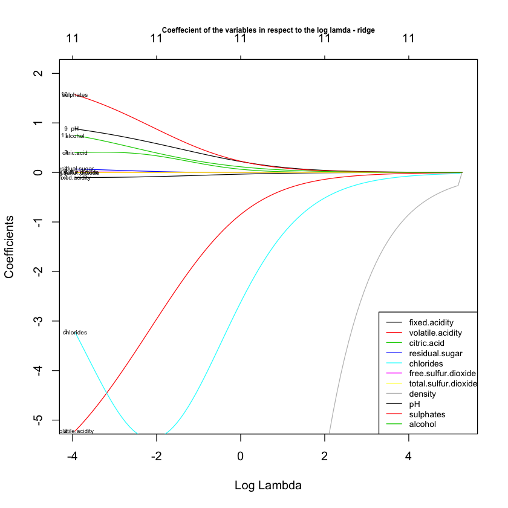

```
Lasso Plots
```

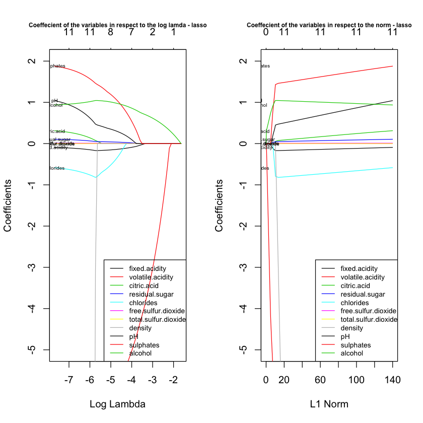

```r
par(mfrow = c(1,1))
pltcoef_las_rdg('0', 'lambda', -5)
title('Coeffecient of the variables in respect to the log lamda - ridge', cex.main = .6)
# pltcoef_las_rdg('0', 'norm')
# title('Coeffecient of the variables in respect to the norm - ridge', cex.main = .6)
par(mfrow = c(1,2))
pltcoef_las_rdg('1', 'lambda', -5)
title('Coeffecient of the variables in respect to the log lamda - lasso', cex.main = .6)
pltcoef_las_rdg('1', 'norm', -5)
title('Coeffecient of the variables in respect to the norm - lasso', cex.main = .6)
cat('\n\nLasso Plots\n')
```

### Summary

Both of the coefficient for Ridge and Lasso was plotted against the log of lambda, which is the weight given to the regularization term for ridge and lasso. As previously mentioned, ridge penalises the least significant coefficients and shrinks it towards 0 and lasso reduces the coefficient to 0. The model was developed on a value grid of approximately 100 values of lambda. As lambda increases, the coefficients are more regularised hence approach or reaching 0, and vice versa.

Both type of plots as indicated above showed different coloured lines that is referenced to the different predictors. They provide similar information, but on a different scale.

#### Ridge

Since Ridge regression penalises the coefficients by shrinking it towards 0, the least important predictors' coefficient will shrinking faster than the more important predictors. In the plot, as the lambda increases, chance of the resulting the probability of 1, which indicates 'good' quality, decreases. Predictors such as chloride, density and volatile acidity shrunk the slowest, as indicated by the first plot, where the line was sparsed widely at the bottom, this indicated that it took a lot of weight of regularization to shrink those coefficient, hence these predictors are most likely to be important to the model. However since ridge retains all predictors, the plot showed that all predictors ended up being close to 0 after the log lambda of 4 was applied.

#### Lasso

The L1 norm, represents the regularization term, where lambda was used as the weight of the term. Or simply the maximum permission value that the L1 norm can take. Hence a small L1 norm (vector space), represents an empty model. As the norm increaes, predictors can join the norm with their coefficients. Predictors that joined the norm early are considered to be relevant to relevant to the response varaible, hence the overall model. Predictors that joins later than others, such as chlorides are less likely to be important to the model.

#### Conclusion

Overall, in order to determine the best model to generate the probability of wine qualities, cross validation, such as 10-folds, within the generalised linear model needs to be considered.

### Ridge and Lasso cross validation

#### Function - coefficient table / plot

```r
las_ridge <- function(dataset, response, o_l, return_type){
    set.seed(135)
    wine_mat <- model.matrix(quality ~., data = dataset)[, -1] # converts to matrix form
    cv_reg <- cv.glmnet(wine_mat, response, alpha = o_l, family = 'binomial') #performs cv to find best lambda
    fit_reg <- glmnet(wine_mat, response, alpha = o_l, family = 'binomial')
    pred <- predict(fit_reg, s = cv_reg$lambda.min, type = "coefficients")[1:12, ] #prediction using best lambda, get coef
    if(return_type == 'coef'){return(cv_reg)}
    else if (return_type == 'table'){return(pred)}
    else if (return_type == 'fit'){return(fit_reg)}
}
```

```
 Coefficient table for ridge
```

**(Intercept)**

87.1451958343423

**fixed.acidity**

-0.102610746564603

**volatile.acidity**

-5.14026515532243

**citric.acid**

0.401518877796143

**residual.sugar**

0.0674764663007324

**chlorides**

-3.37579370197775

**free.sulfur.dioxide**

0.0102554217164973

**total.sulfur.dioxide**

-0.00244513746447205

**density**

-96.4407497608324

**pH**

0.868100599616009

**sulphates**

1.54497863093081

**alcohol**

0.734915325438314

```
 Coefficient table for lasso
```

**(Intercept)**

-9.57954329391435

**fixed.acidity**

-0.162741317530737

**volatile.acidity**

-6.25571325754133

**citric.acid**

0

**residual.sugar**

0.0457160034320447

**chlorides**

-0.669870348492044

**free.sulfur.dioxide**

0.00794412998171784

**total.sulfur.dioxide**

-0.000370522264162592

**density**

0

**pH**

0.406549971353598

**sulphates**

1.33838818343484

**alcohol**

1.03324969826718

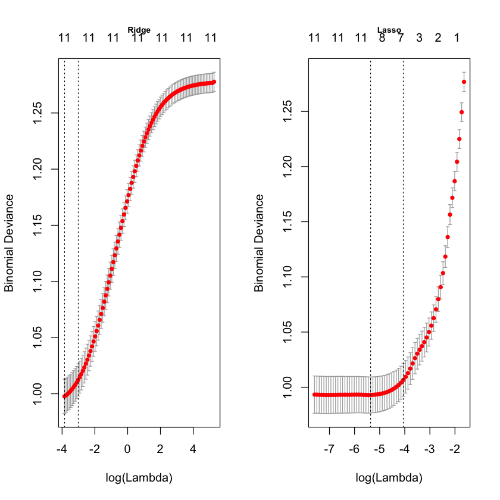

```r
par(mfrow = c(1,2))
coef_ridge <- las_ridge(wine, wine$quality, 0, 'coef')
plot(coef_ridge)
title('Ridge', cex.main = .7)
cat('\n Coefficient table for ridge\n')
las_ridge(wine, wine$quality, 0, 'table')


coef_lasso <- las_ridge(wine, wine$quality, 1, 'coef')
plot(coef_lasso)
title('Lasso', cex.main = .7)
cat('\n Coefficient table for lasso\n')
las_ridge(wine, wine$quality, 1, 'table')
```

#### Seed

The seed was set to be 135, this made sure that when the result were reproduced, the same result would show. However it should be noted that the coefficiens of the predictors in lasso and ridge fluactuates depending on the minimum lambda value generated by 10 folds cross validation. If the same seed is not used the coefficient value would vary, but slightly, still indicating which predictors are mostly affected by the regularization term.

#### Coefficient table and plot

Although in Ridge all predictors are chosen, however predictors such as free sulfure dioxide, total sulfure dioxide and residual sugar, are heavily penalised by the regularization, hence having the lowest coefficients when compared to other variables.

In lasso, citric acid, and density are heavily penalised to 0, and predictors' coefficient such as total sulfur dioxide and free sulfur dioxide are insignificant. These coefficients varies with the cross validation. The seed was set so that the result is static, however the main concept is the penalty that lambda has on the regularisation of each predictors.

This showed that lasso selected only 9 varaibles as the predictors for the best model. This can also be seen on the lasso plot, where the second vertical line is marked on the lasso plot. The plot showed that a model with 7 predictors is within one standard error of the mean of all model (second dashed line), hence it is likely that the least significant predictors, as denoted by its coefficient, did not affect the model's power in predicting. This leaves the model with approximately 7 predictors in total that are important to the model.

Final model for Ridge and Lasso is as shown below:

> **Ridge - full model**, with shrunked coefficients

> **Lasso - quality ~ fixed acidity + volatile acidity + residual sugar + chlorides + free sulfur dioxide + total sulfur dioxide + pH + sulphates + alcohols**, with shrunked coefficients

# Model performance comparisong - Stepwise, Ridge, Lasso

### Fitting model chosen in stepwise as the final model

#### Function - Three models cross validation (AUC)

```r
cv_best_model2 <- function(resp_pred, alphatype){
    pred_acc <- NULL #initiates a list
    for(i in 1:10){ #10 folds
        train_set <- cv_set(10, i, wine, 'train')
        test_set <- cv_set(10, i, wine, 'test')

        if(length(resp_pred) > 0){ #checks if there anything in first parameter of the function
            model <- glm(paste(resp_pred), data = train_set, family = 'binomial') #pastes the formular into log function
            pred <- auc_roc(model, test_set, 'auc') #calculates predictive accuracy
            pred_acc <- c(pred_acc, pred) #stores the value in a list
        } else if (alphatype == 1 | alphatype == 0){

            x <- model.matrix(quality ~ ., data = train_set)[, -1]
            cv_glm <- cv.glmnet(x, train_set$quality, alpha = alphatype, family = 'binomial')
            bestlam <- cv_glm$lambda.min
            glm_output <- glmnet(x, train_set$quality, alpha = alphatype, family = 'binomial')
            x2 <- model.matrix(quality ~ ., data = test_set)[,-1]

            las_ridge_pred <- predict(glm_output, s = bestlam, newx = x2)

            pred <- prediction(las_ridge_pred, test_set$quality)
            auc <- performance(pred, measure = 'auc')@y.values[[1]] #uses AUC as measurement, converts to vector space
            pred_acc <- c(pred_acc, auc)
        }
    }
    return(mean(pred_acc)*100)
}
```

#### Function - Three models AUC

```r
single_auc_final <- function(resp_pred, alphatype, trainingSet, testingSet){
    if(length(resp_pred) > 0){
        model <- glm(paste(resp_pred), data = trainingSet, family = 'binomial') #pastes the formular into log function
        pred <- auc_roc(model, testingSet, 'auc') #calculates predictive accuracy
        return(pred)
    } else if (alphatype == 1 | alphatype == 0){
        x <- model.matrix(quality ~ ., data = trainingSet)[, -1]
        cv_glm <- cv.glmnet(x, trainingSet$quality, alpha = alphatype, family = 'binomial')
        bestlam <- cv_glm$lambda.min
        glm_output <- glmnet(x, trainingSet$quality, alpha = alphatype, family = 'binomial')
        x2 <- model.matrix(quality ~ ., data = testingSet)[,-1]
        las_ridge_pred <- predict(glm_output, s = bestlam, newx = x2)
        pred <- prediction(las_ridge_pred, testingSet$quality)
        auc <- performance(pred, measure = 'auc')@y.values[[1]]
        return(auc)
    }
}
```

```r
auc_list <- c(cv_best_model2('quality ~ alcohol + volatile.acidity + residual.sugar + fixed.acidity + sulphates', NULL),
             cv_best_model2(NULL, alphatype = 0), cv_best_model2(NULL, alphatype = 1))
best_model_sel <- data.frame(c('Stepwise Model', 'Ridge', 'Lasso'), auc_list)
cat('\nTable of the area under the curve for each model types on CV train set\n')
best_model_sel

cat('\n\nTable of the area under the curve for each model types on test set\n')
auc_final_model <- c(single_auc_final('quality ~ alcohol + volatile.acidity + residual.sugar + fixed.acidity + sulphates',
                 NULL, wine, test_wine), single_auc_final(NULL, alphatype = 0, wine, test_wine),
                    single_auc_final(NULL, alphatype = 1, wine, test_wine))
final_model_df <- data.frame(c('Stepwise Model', 'Ridge', 'Lasso'), auc_final_model)
final_model_df
```

```
Table of the area under the curve for each model types on CV train set
```

|  | c..Stepwise.Model....Ridge....Lasso.. | auc_list |
| --- | --- | --- |
| 1 | Stepwise Model | 80.8403521069528 |
| 2 | Ridge | 80.9022149292862 |
| 3 | Lasso | 80.7926271655456 |

```
Table of the area under the curve for each model types on test set
```

|  | c..Stepwise.Model....Ridge....Lasso.. | auc_final_model |
| --- | --- | --- |
| 1 | Stepwise Model | 0.751903883449221 |
| 2 | Ridge | 0.762991343834254 |
| 3 | Lasso | 0.762688614540465 |

## Overall Best Model

The model was cross validated using 10 folds on the training set. AUC was used as the measurement of performance to be the measurement of performance as previously mentioned in the forward stepwise process. Upon cross validation of the 3 models, from 3 different approaches, the Ridge model had the highest AUC however the stepwise model is just slightly below, followed by Lasso. Although the seed was set within the function to ensure the same result could be reproduced. Changing the seed would cause the performance score to vary slightly, but still indicate the best model from the cross validation is Ridge, followed by Stepwise then Lasso.

#### Stepwise Model

Advantages

> The apporach of forward stepwise allowed each predictors to be compared by adding one predictor at a time if it had the highest AUC. This process of searching for all possible combination gives a good indication of which predictor is useful based on the training dataset. This reduces model complexity, and directly prepares the model to be used on the test data to identify it's prediction performance.

Distadvantages

> Stepwise has many disadvantages, and this is famously noted by Altman and Andersen (1989). The coefficients produced for each of the predictors that are not exluded are biased towards to training data, hence they are much larger than what they are meant to be. Nevertheless this method of stepwise was done using the concept of AUC, and keeping on the predictors that have the highest AUC. When refering back to the best model produced by this, density was not included. Hence it causes an issue of colinearity, as density is highly correlated with alcohol and residual sugar, in which both of these predictors are included, the removal of density could have affected the prediction of the test error of the model.

#### Ridge Model

Advantages

> Although ridge is not a method of variable selection, it adds a regularization term to the regression, hence shrinking the coefficient and overall reducing the chance of overfitting. This decreases both variance and bias in the prediction performance. Another advantage is that if there are synergy between variable, such as that there are predictors that are collinear, ridge regression does not disregard the relationship between those predictors by removing them. However as colinearity creates a problem where the variance of the parameter ends up being large, ridge introduces bias to reduce the large varaince.

Distadvantages

> A major disadvantage of ridge is although it applies regularization term to shrink the coefficient of the model, it does not remove them, hence why it is not a method for variable selection. This leads to a higher chance of the model being overfitting when compared to lasso or the forward stepwise approach. Nevertheless the model can also become highly complex in interpretation, as the number of predictors increases.

#### Lasso Model

Advantages

> One of the major advatange of Lasso, unlike ridge, is that it helps select the variable for the final model. When the number of predictors are large, intepreting is difficult. However as lasso makes the coefficient 0 for the least important variables, the interpretation is not an issue.

Distadvantages

> One of the issue with this penalization approach is that as it converges predictors that are deemed to be irrelavent to 0. It could be that the variable are actually important in the test dataset. Also, in the final model of lasso, using the corresponding seed as indicated, it showed that density was removed. Upon looking at the scatterplot matrix, density has a strong relationship with alcohol and residual sugar, as well as some relationship with total sulfur dioxide. This issue of multicollinearity, occurs within Lasso as it tends to penalize one of the predictor that is highly correlated with another, in this case it was density. The synergy between predictors should be removed as a group or selected as a set.

#### Best Model - Ridge

> All three approaches were fitted onto the provided testing set in order to determine its prediction performance, AUC. As shown in the table above, stepwise had the smallest AUC. This would be due to that some variables that were removed were infact important in the testing set. Ridge and Lasso were not far off, both giving similar results, however ridge outperformed Lasso. This is most likely due to the fact that although Ridge kept all of the predictors, it also kept the predictors that are colinear with one another, but still penalising them accordinaly. This would cause a slight improvement to the prediction performance when compared to lasso.

# Reference

The stepwise method was inspired by reading this article, and also to get the disadvantages of stepwise approach:

Charpentier, A 2015, 'Variable Selection Using Cross Validation (And Other Technques)', *Statistics*, viewed 15 September 2015, http://freakonometrics.hypotheses.org/19925